# Computational Musicology 2025

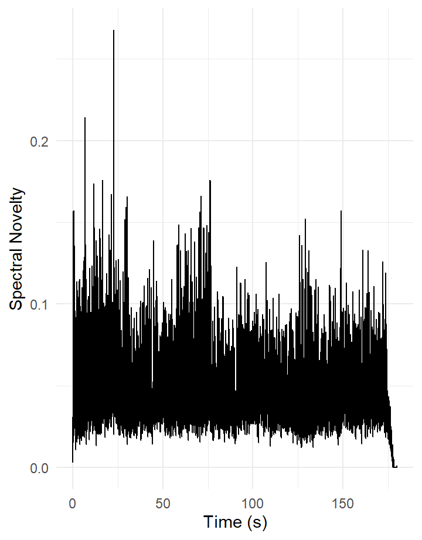

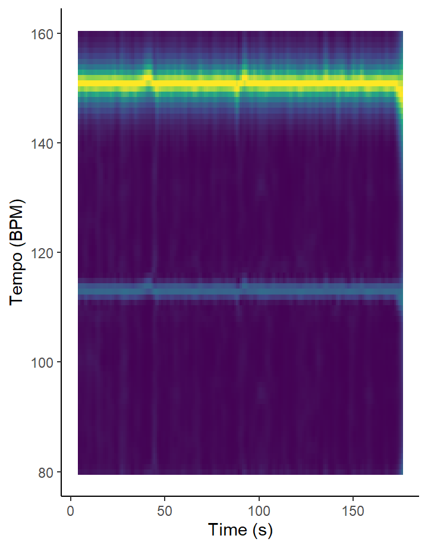

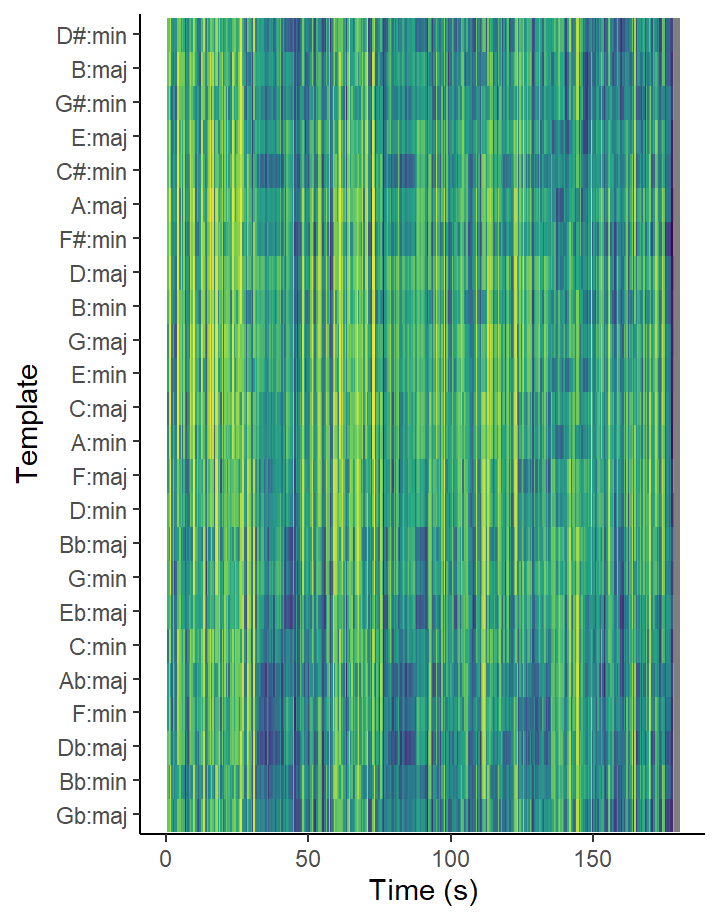

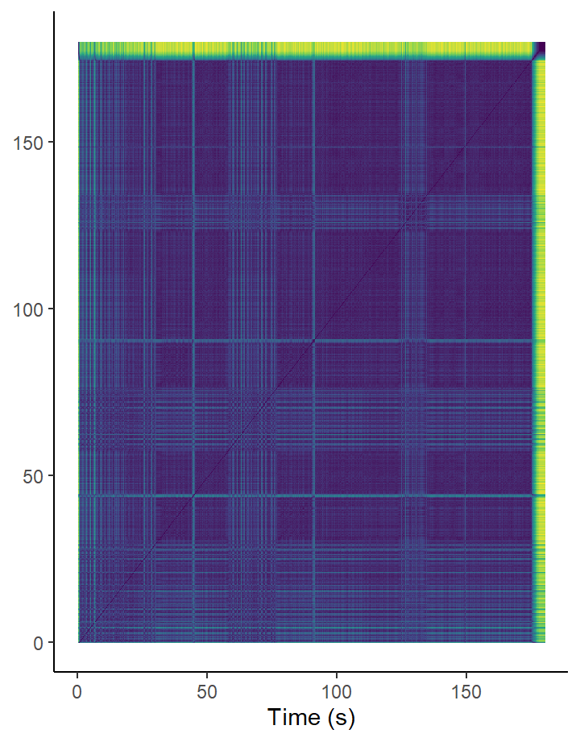

[figure not shown]

### Novelty function

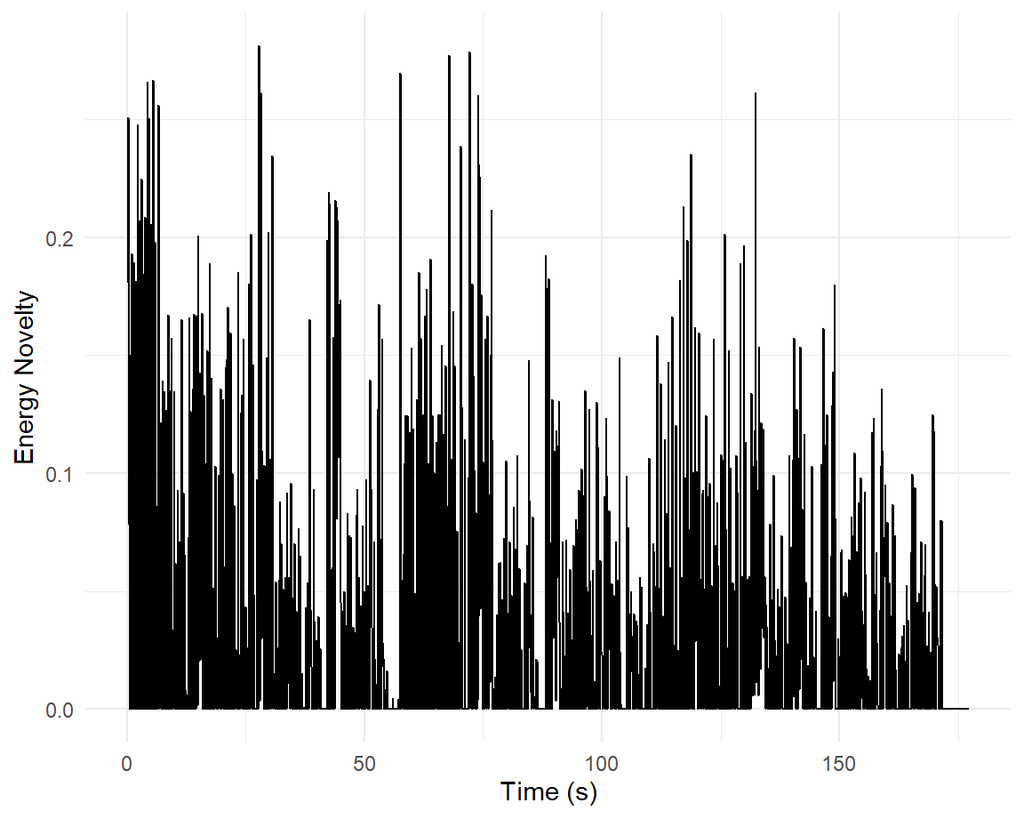

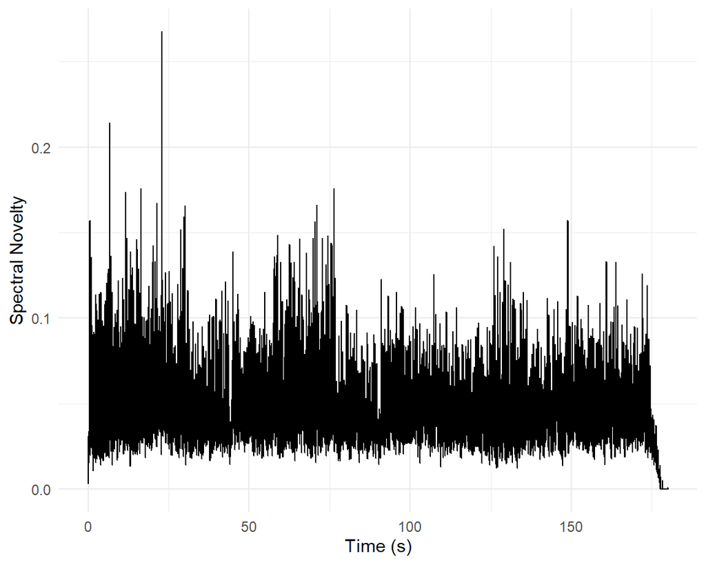

Here we see an **energy novelty** plot and a **spectral novelty** plot. They look sick.

### Tempograms

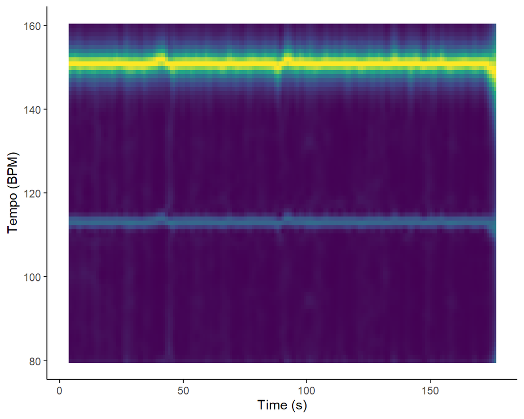

Here we see an **Tempogram**. This looks absolutely insane does it not? very cool

### Chordogram & keygram

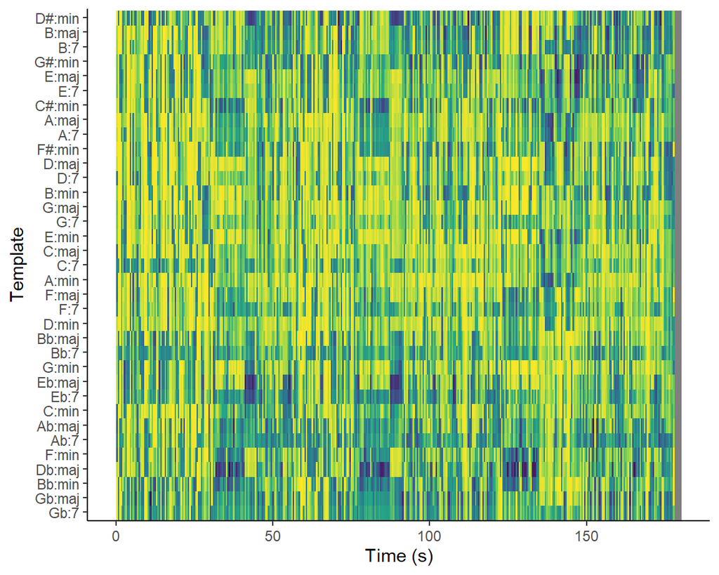

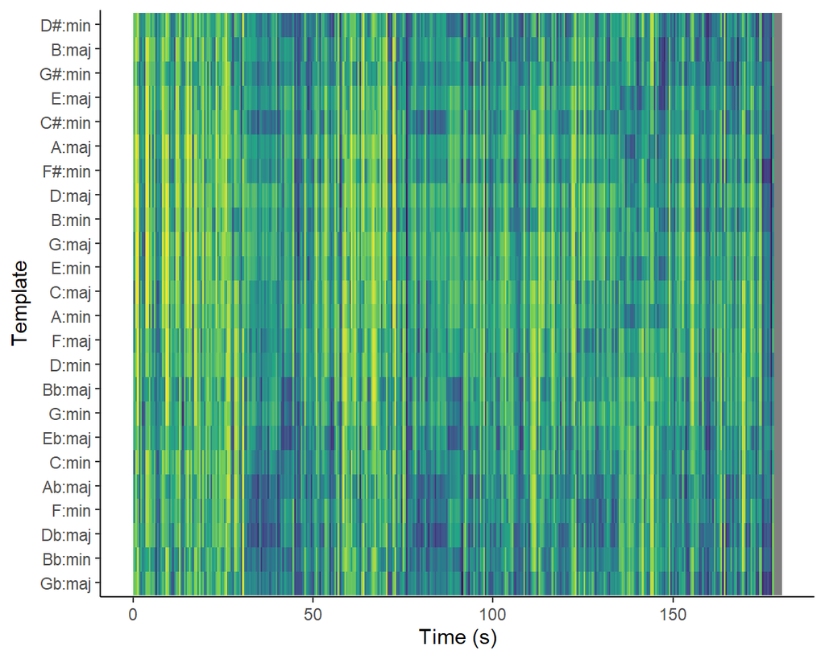

- **In the plots we can see a chordogram and a keygram respectively. My tracks are not yet in the corpus unfortunately, so the tracks that are visible are those of Berend-2. When my tracks are added I will go deeper into the analysis. The norm right now is euclidean and the distance is cosine**.

-A **chordogram** is a visual representation of the harmonic structure of a musical piece, showing the distribution and progression of chords over time. It often appears as a heatmap or graph, highlighting the frequency and transitions of different chords, helping musicologists analyze harmonic patterns, tonality, and stylistic tendencies. Chordograms are especially useful in computational musicology to compare harmonic trends across genres or historical periods.

-A **keygram** is a graphical tool that represents the tonal centers or key changes within a musical composition. By mapping the prominence of different keys throughout a piece, it helps reveal modulations, stability, and tonal hierarchies. Keygrams are valuable for understanding the structural flow of a piece and are often used in automatic key detection and comparative music analysis.

### Timbre & Chroma Analysis

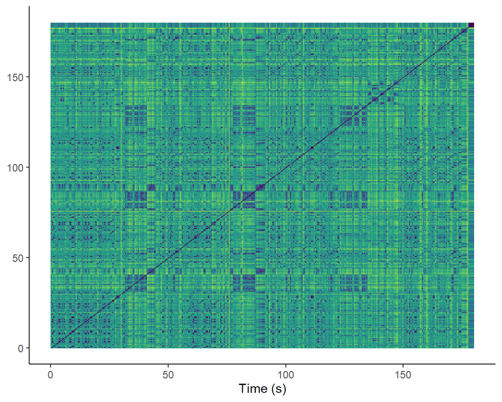

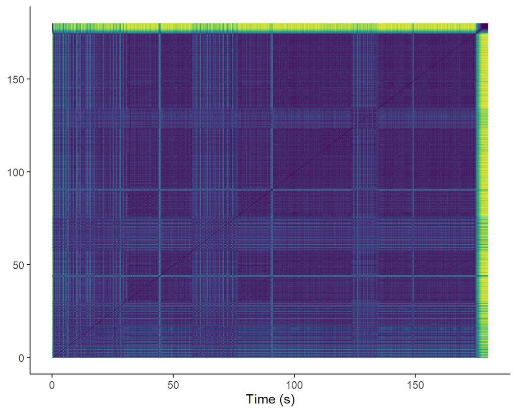

Explanation: Chroma & Timbre Analyse

- **Chroma Self-Similarity:** this plot is visualizing the harmonic structure of a musical piece.Patterns in the chroma self similarity can point to repeating chords and music scales. The song chosen is the first track from Berend. This is because my tracks are unfortunatly not yet in the corpus. So I will explain this plot as soon as it is my song. The same goes for the timbre self similarity plot
- **Timbre (MFCC) Self-Similarity:** This represents the timbre of the song. Variations in timbre can be related to instrumentelness and dynamics.

By looking at the plots together we can look at similarities between the plots and maybe see some interesting patterns.

### Welcome to Computational Musicology 2025!

Welcome to Computational Musicology 2025! This is going to be the intro page for the final portfolio

### Welcome to my portfolio!

Below are two tracks. Click the play buttons to listen to each track.

Track 1 is an AI generated track on stable audio with the following prompt: New wave, punk pop, rhythmic guitar riffs, upbeat bassline, driving drums, quirky synths, energetic girl vocals, melodic, retro vibes, 70s/80s influence, playful, danceable, confident, cheeky lyrics, funky groove, fast tempo, pop with attitude.

Track 2 is an AI generated track generated by stable audio with the prompt: Electronic, French house, funky bassline, robotic vocals, vocoder, disco groove, punchy drum machines, retro-futuristic synths, filter sweeps, crisp hi-hats, four-on-the-floor beat, hypnotic loops, atmospheric pads, analog warmth, danceable, smooth yet energetic.

#### Track 1

[interactive chart not shown]

#### Track 2

[interactive chart not shown]

### Visualising the AI Song Contest

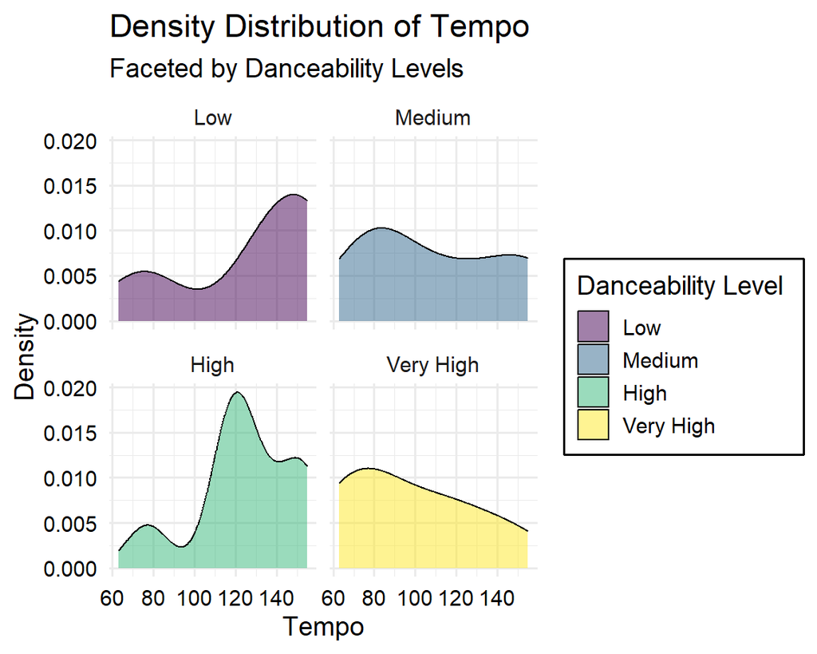

[interactive chart not shown]

Exploring Tempo Distributions This density plot visualizes the distribution of tempos in the AI Song Contest dataset. The x-axis represents tempo (beats per minute, BPM), while the y-axis shows density, indicating how frequently different tempo ranges appear in the dataset.

The fill color represents danceability, meaning that more danceable songs are highlighted in different shades. This allows us to explore whether certain tempos are more common in highly danceable tracks.

Key Insights: The dataset shows clear peaks, suggesting that AI-generated songs tend to favor specific tempo ranges. The smooth distribution helps identify whether AI compositions cluster around conventional musical tempo patterns or diverge from human-created norms. By incorporating danceability, we gain additional insight into the relationship between rhythmic elements and listener engagement. This visualization helps us understand how AI-generated music organizes rhythmic elements, potentially revealing biases or preferences in algorithmic composition.

### Discussion: Insights & Next Steps

- **Patterns observed:** The dataset shows clear peaks, suggesting that AI-generated songs tend to favor specific tempo ranges. The smooth distribution helps identify whether AI compositions cluster around conventional musical tempo patterns or diverge from human-created norms.
- **Limitations:** The dataset lacks information on lyrical content and emotional perception.

### My Tracks & Creation Process

This repository also includes original compositions. These tracks were created using AI-assisted composition tools. The goal was to experiment with algorithmic composition techniques while maintaining human musical intuition.